## Reproducible Research Course Project: Costs and Impact on Population Health of Climatic Events accross USA

Author: E. Mineo Date: 4 September 2018

# Data Processing

```r
data <- "https://d396qusza40orc.cloudfront.net/repdata%2Fdata%2FStormData.csv.bz2"
download.file(data, "./data/StormData.bz2")
df <- read.csv("./data/StormData.bz2")
```

```r
library(lubridate)
library(dplyr)
library(reshape2)
library(ggplot2)
```

A new dataframe is created with only the relevant variables

```r
df2 <- df[,c(8,23:28)]
str(df2)
```

```
## 'data.frame':    902297 obs. of  7 variables:
##  $ EVTYPE    : Factor w/ 985 levels "   HIGH SURF ADVISORY",..: 834 834 834 834 834 834 834 834 834 834 ...
##  $ FATALITIES: num  0 0 0 0 0 0 0 0 1 0 ...
##  $ INJURIES  : num  15 0 2 2 2 6 1 0 14 0 ...
##  $ PROPDMG   : num  25 2.5 25 2.5 2.5 2.5 2.5 2.5 25 25 ...
##  $ PROPDMGEXP: Factor w/ 19 levels "","-","?","+",..: 17 17 17 17 17 17 17 17 17 17 ...
##  $ CROPDMG   : num  0 0 0 0 0 0 0 0 0 0 ...
##  $ CROPDMGEXP: Factor w/ 9 levels "","?","0","2",..: 1 1 1 1 1 1 1 1 1 1 ...
```

Here we check whether there are NA values in the variables we are interested in.

```r
sum(is.na(df2$FATALITIES))
```

```
## [1] 0
```

```r
sum(is.na(df2$INJURIES))
```

```
## [1] 0
```

```r
sum(is.na(df2$PROPDMG))
```

```
## [1] 0
```

```r
sum(is.na(df2$CROPDMG))
```

```
## [1] 0
```

Here we check how many event types the dataset contains.

```r
length(unique(df2$EVTYPE))
```

```
## [1] 985
```

```r
df2$EVGRP <- "" #create new column for group names

df2$EVTYPE <- tolower(df2$EVTYPE)

df2[!grepl("coastal|flash",df2$EVTYPE)&grepl("flood|fld",df2$EVTYPE),8] <- "flood"
df2[grepl("flash",df2$EVTYPE),8] <- "flash flood"
df2[grepl("coastal",df2$EVTYPE),8] <- " coastal flood"
df2[grepl("storm surge|tide|rising water|high water",df2$EVTYPE),8] <- "storm surge/tide"
df2[grepl("avalan",df2$EVTYPE),8] <- "avalanche"
df2[grepl("blizzard",df2$EVTYPE),8]<- "blizzard"
df2[grepl("cold|low temperature",df2$EVTYPE)&!grepl("extreme cold",df2$EVTYPE),8] <- "cold/wind chill"
df2[grepl("extreme cold|hypothermia",df2$EVTYPE),8] <- "extreme cold"
df2[grepl("fog",df2$EVTYPE),8] <- "dense fog"
df2[grepl("drought",df2$EVTYPE),8] <- "drought"
df2[grepl("devil",df2$EVTYPE),8] <- "dust devil"
df2[grepl("dust storm",df2$EVTYPE),8] <- "dust storm"

heat_str<- unique(df2[grepl("heat",df2$EVTYPE),1])
heat_str2 <- heat_str[2:9]
for (i in heat_str2) {df2[grepl(i,df2$EVTYPE),8] <- "excessive heat"}

df2[grepl("^heat$",df2$EVTYPE),8] <- "heat"
df2[grepl("frost|freeze",df2$EVTYPE),8] <- "frost/freeze"
df2[grepl("funnel",df2$EVTYPE),8] <- "funnel cloud"
df2[grepl("freezing",df2$EVTYPE),8] <- "freezing fog"
df2[grepl("^hail$",df2$EVTYPE),8] <- "hail"
df2[grepl("^small hail$",df2$EVTYPE),8] <- "hail"
df2[grepl("thunderstorm|tstm",df2$EVTYPE) & !grepl("^marine thunderstorm wind$",df2$EVTYPE),8] <- "thunderstorm"
df2[grepl("^marine thunderstorm wind$|^marine tstm wind$",df2$EVTYPE),8] <- "marine thunderstorm wind"
df2[grepl("rain",df2$EVTYPE),8] <- "heavy rain"
df2[grepl("snow",df2$EVTYPE),8] <- "heavy snow"
df2[grepl("surf|high waves|high swells|rough seas|high seas|heavy seas|rogue wave",df2$EVTYPE),8] <- "high surf"
df2[grepl("high wind",df2$EVTYPE)&!grepl("snow",df2$EVTYPE),8] <- "high wind"
df2[grepl("wind",df2$EVTYPE)&!grepl("high wind|tstm|thunderstorm|cold|rain|surf",df2$EVTYPE),8] <- "strong wind"
df2[grepl("hurricane|typhoon",df2$EVTYPE),8] <- "hurricane (typhoon)"
df2[grepl("ice|icy",df2$EVTYPE)&!grepl("snow|flash flood",df2$EVTYPE),8] <- "ice storm"
df2[grepl("lightning",df2$EVTYPE),8] <- "lightning"
df2[grepl("marine",df2$EVTYPE)&!grepl("wind",df2$EVTYPE),8] <- "marine thunderstorm wind"
df2[grepl("current",df2$EVTYPE),8] <- "rip current"
df2[grepl("sleet",df2$EVTYPE),8] <- "sleet"
df2[grepl("tornado",df2$EVTYPE),8] <- "tornado"
df2[grepl("tropical",df2$EVTYPE),8] <- "tropical storm"
df2[grepl("tsunami",df2$EVTYPE),8] <- "tsunami"
df2[grepl("^waterspout$",df2$EVTYPE),8] <- "waterspout"
df2[grepl("fire",df2$EVTYPE),8] <- "wildfire"
df2[grepl("winter storm",df2$EVTYPE),8] <- "winter storm"
df2[grepl("winter weather",df2$EVTYPE),8] <- "winter weather"
df2[grepl("slides|slide",df2$EVTYPE),8] <- "landslides"

df2[which(df2$EVGRP==""),8] <- "other"

unique(df2$EVGRP)
```

```
##  [1] "tornado"                  "thunderstorm"
##  [3] "hail"                     "heavy rain"
##  [5] "heavy snow"               "flash flood"
##  [7] "winter storm"             "hurricane (typhoon)"
##  [9] "cold/wind chill"          "lightning"
## [11] "dense fog"                "rip current"
## [13] "high wind"                "funnel cloud"
## [15] "heat"                     "strong wind"
## [17] "other"                    "flood"
## [19] "waterspout"               "extreme cold"
## [21] "blizzard"                 "frost/freeze"
## [23] " coastal flood"           "storm surge/tide"
## [25] "ice storm"                "avalanche"
## [27] "marine thunderstorm wind" "high surf"
## [29] "excessive heat"           "dust storm"
## [31] "sleet"                    "dust devil"
## [33] "wildfire"                 "landslides"
## [35] "freezing fog"             "winter weather"
## [37] "drought"                  "tropical storm"
## [39] "tsunami"
```

The propriety and crop damages numbers need to be expressed in the same unit in order to be compared.

```r
df2$prop_dmg <-"" #create new column for the propriety damages in USD
df2$crop_dmg <-"" #create new column for the crop damages in USD

#convert all numbers in the same unit
df2[df2$PROPDMGEXP=="",9] <- df2[df2$PROPDMGEXP=="",4]
df2[df2$PROPDMGEXP=="0",9] <- df2[df2$PROPDMGEXP=="0",4]
df2[df2$PROPDMGEXP=="K",9] <- df2[df2$PROPDMGEXP=="K",4]*1000
df2[df2$PROPDMGEXP=="M",9] <- df2[df2$PROPDMGEXP=="M",4]*1000000
df2[df2$PROPDMGEXP=="B",9] <- df2[df2$PROPDMGEXP=="B",4]*1000000000

df2[df2$CROPDMGEXP=="",10] <- df2[df2$CROPDMGEXP=="",6]
df2[df2$CROPDMGEXP=="0",10] <- df2[df2$CROPDMGEXP=="0",6]
df2[df2$CROPDMGEXP=="K",10] <- df2[df2$CROPDMGEXP=="K",6]*1000
df2[df2$CROPDMGEXP=="M",10] <- df2[df2$CROPDMGEXP=="M",6]*1000000
df2[df2$CROPDMGEXP=="B",10] <- df2[df2$CROPDMGEXP=="B",6]*1000000000
```

Now that the dataset is cleaned up, we can calculate averages to determine consequences on health and economy.

# Data Analysis and Results

1/Overview count of events from 1950 to 2011

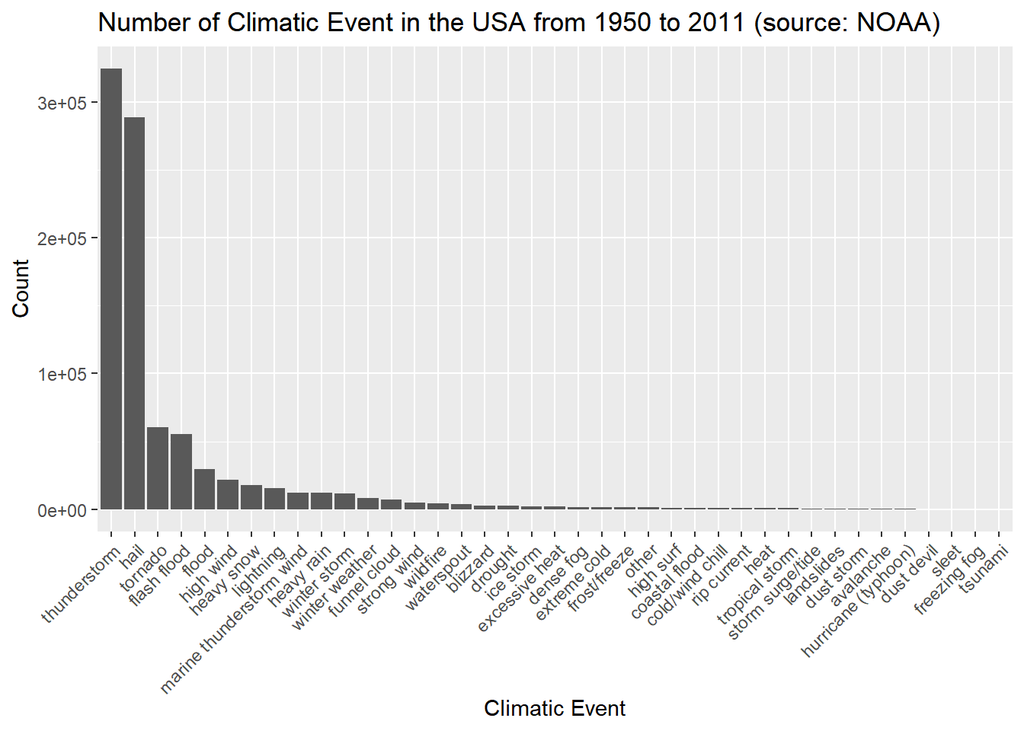

```r
qplot(reorder(EVGRP,EVGRP,function(x) length(x)*-1),
   data=df2,geom="bar",xlab="Climatic Event",ylab="Count",main="Number of Climatic Event in the USA from 1950 to 2011 (source: NOAA)")+
        theme(axis.text.x = element_text(angle = 45, vjust = 1, hjust=1))
```

Figure 1: Number of climatic events in the USA from 1950 to 2011.

The three most frequent events in the period 1950-2011 accross the USA was thunderstorm and the least frequent event was tsunami.

2/ Events Consequences on Population Health

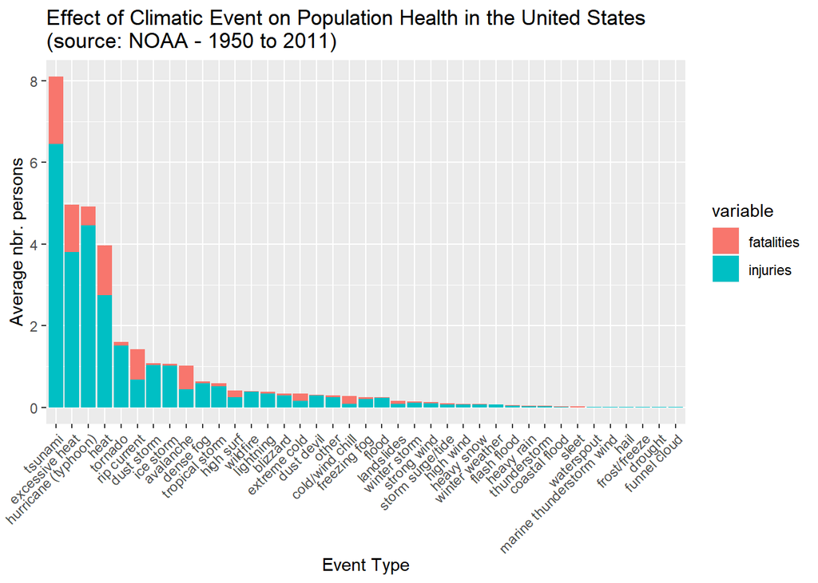

```r
df2_group <- summarize(
  group_by(df2,EVGRP),
  fatalities=mean(FATALITIES),
  injuries=mean(INJURIES))

m.df2_group <- melt(df2_group, id.vars="EVGRP")

ggplot(m.df2_group,aes(x=reorder(EVGRP,-value),y=value))+
        geom_bar(stat="identity", aes(fill=variable))+
        theme(axis.text.x = element_text(angle = 45, vjust = 1, hjust=1))+
        xlab("Event Type")+ylab("Average nbr. persons")+
        ggtitle("Effect of Climatic Event on Population Health in the United States
(source: NOAA - 1950 to 2011)")
```

Fgure 2: Effect of climatic event on population health in the United States.

Interestingly, the event type that has the most impact on population health on average is tsunami, although this is one of the rarest event. Hurricane heatis the second cause of most injuries and heat is the second cause of fatalities.

3/Events Consequences on US Enconomy

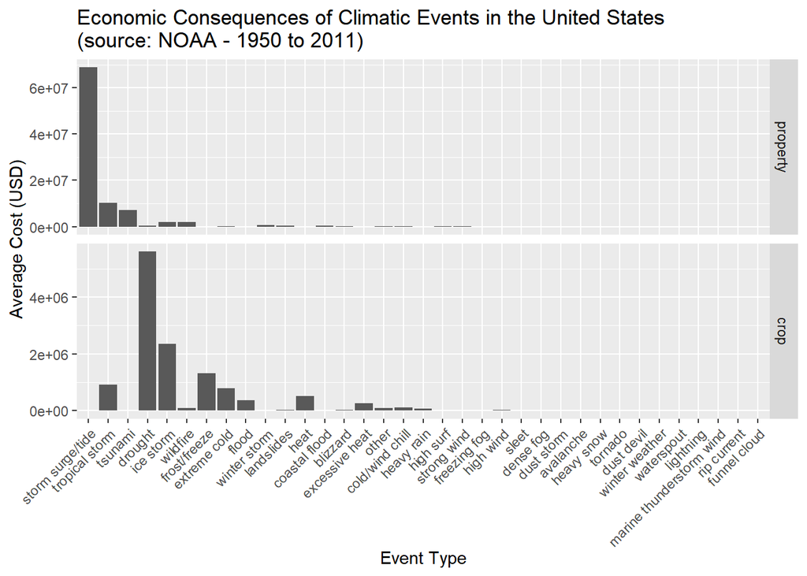

```r
df2$prop_dmg <- as.numeric(df2$prop_dmg)
df2$crop_dmg <- as.numeric(df2$crop_dmg)

df2_dmg_group <- summarize(
  group_by(df2,EVGRP),
  property=mean(prop_dmg),
  crop=mean(crop_dmg))

m.df2_dmg_grp <- melt(df2_dmg_group,id.vars="EVGRP")#transforms matrix data into dataframe

m.df2_dmg_grp2 <- m.df2_dmg_grp[!m.df2_dmg_grp$value=="0",]

m.df2_dmg_grp2 <- m.df2_dmg_grp2[complete.cases(m.df2_dmg_grp2),]

ggplot(m.df2_dmg_grp2,aes(x=reorder(EVGRP,-value),y=value))+
        geom_bar(stat="identity")+
        facet_grid(rows=vars(variable), scales="free")+
        theme(axis.text.x = element_text(angle = 45, vjust = 1, hjust=1))+
        xlab("Event Type")+ylab("Average Cost (USD)")+
        ggtitle("Economic Consequences of Climatic Events in the United States
(source: NOAA - 1950 to 2011)")
```

Figure 3: Economic consequences of climatic events in the USA

Storms caused the most damages on property and drought caused the most damage on crops. The second most costly damages are caused by tropical storm on property and ice storm on crops.